# Técnicas Estadísticas con Información Imprecisa

Práctica 1

Víctor Marín Juarros y Juan José Martín Miralles

**El fichero *frontur_2017.txt* contiene la información sobre los datos por comunidades autónomas de *Movimientos Turísticos en Fronteras (FRONTUR)* de diciembre de 2017 (datos provisionales a 1 de febrero de 2018) en España. Las columnas correspondientes a las variables están separadas por espacios y contienen una primera fila con el nombre de las variables. Las variables son las siguientes:**

- *comunidad*: Nombre de la comunidad autónoma de España.
- *turistas*: Nombre acumulado de turistas internacionales en valor absoluto en 2017.

*Fuente:* INE-FRONTUR (http://www.ine.es)

## Ejercicio 1

**Descarga el fichero y define un dataframe. Comprueba con *str* y *head* que se ha descargado correctamente y comprueba los nombres de las variables.**

```r
df = read.csv("frontur_2017.txt", sep = " ")
head(df)
```

|  | comunidad | turistas |
| --- | --- | --- |
| 1 | Andalucía | 11530070 |
| 2 | Baleares | 13790968 |
| 3 | Canarias | 14213686 |
| 4 | Cataluña | 19046720 |
| 5 | CValenciana | 8918327 |
| 6 | CMadrid | 6694686 |

```r
str(df)
```

```
## 'data.frame':    7 obs. of  2 variables:
##  $ comunidad: Factor w/ 7 levels "Andalucía","Baleares",..: 1 2 3 4 6 5 7
##  $ turistas : int  11530070 13790968 14213686 19046720 8918327 6694686 7591906
```

## Ejercicio 2

**Añade una nueva columna con la población de cada comunidad autónoma de forma *crisp* (de toda la vida). Puedes encontrar los datos aquí:** http://www.ine.es/jaxiT3/Tabla.htm?t=9681&L=0

```r
poblacion = c(8403350, 1160591, 2164344, 7453957, 4932302, 6506437, 15928064)
df$poblacion = poblacion
df
```

| comunidad | turistas | poblacion |
| --- | --- | --- |
| Andalucía | 11530070 | 8403350 |
| Baleares | 13790968 | 1160591 |
| Canarias | 14213686 | 2164344 |
| Cataluña | 19046720 | 7453957 |
| CValenciana | 8918327 | 4932302 |
| CMadrid | 6694686 | 6506437 |
| OtrasCA | 7591906 | 15928064 |

## Ejercicio 3

**Carga el paquete *FuzzyNumbers*, fuzzifica los datos de visitantes seguiendo algún criterio, después de leer el documento de metodología para extraer estos datos (por ejemplo, un porcentaje concreto del total o un porcentaje en función de la población). Haz la gráfica de cada uno de los datos.**

Para la Fuzzyficación de nuestros datos tendremos en cuenta dos variables: el número de turistas que acceden al país por tren, y los que acceden por carretera, descartando aquellos que llegar por avión y mar. El motivo de esta elección se basa en la metodología para el cálculo de los turístas que se menciona en la nota de prensa, que mientras que para mar y aire se obtienen datos exactos de las autoridades aéreas y marítimas, las correspondientes a carretera están estimadas en función del país de procedencia, con lo cual el número de pasajeros en cada vehículo puede estar sesgado, y por tren ya que es un medio de transporte que puede no ser del todo minucioso en lo que a control se refiere.

Dicho esto, añadimos a la cantidad de turistas esta imprecisión, tomando un 10% sobre el total en el caso de turistas que han llegado por carretera, y un 1% sobre el total de turistas que han llegado en tren. El número total de turistas que llegan por cada vía de acceso se encuentra en la tabla **Llegada de turistas internacionales según vías de acceso**. A Baleares y Canarias no se le ha aplicado ningún dato de imprecisión sobre estos accesos debido a que no llegan por carretera ni por tren a las islas.

```r
imprecision_carretera = c(1287759.8, 0, 0, 1287759.8, 1287759.8, 1287759.8, 1287759.8)
imprecision_tren = c(37357.1, 0, 0, 37357.1, 37357.1, 37357.1, 37357.1)
df$imprecision_carretera = imprecision_carretera
df$imprecision_tren = imprecision_tren

df$porcentaje_tur = df$turistas / sum(df$turistas)
df$porcentaje_pob = df$poblacion / sum(df$poblacion)

df
```

| comunidad | turistas | poblacion | imprecision_carretera | imprecision_tren | porcentaje_tur | porcentaje_pob |
| --- | --- | --- | --- | --- | --- | --- |
| Andalucía | 11530070 | 8403350 | 1287760 | 37357.1 | 0.14097790 | 0.18052680 |
| Baleares | 13790968 | 1160591 | 0 | 0.0 | 0.16862185 | 0.02493265 |
| Canarias | 14213686 | 2164344 | 0 | 0.0 | 0.17379042 | 0.04649599 |
| Cataluña | 19046720 | 7453957 | 1287760 | 37357.1 | 0.23288381 | 0.16013126 |
| CValenciana | 8918327 | 4932302 | 1287760 | 37357.1 | 0.10904418 | 0.10595925 |
| CMadrid | 6694686 | 6506437 | 1287760 | 37357.1 | 0.08185577 | 0.13977595 |
| OtrasCA | 7591906 | 15928064 | 1287760 | 37357.1 | 0.09282606 | 0.34217810 |

El core está compuesto por el número de turistas menos y más (hacia la izquiera y hacia la derecha) la imprecisión mostrada en la gráfica anterior. El soporte será el número de turistas menos o más la imprecisión y menos o más el número de turistas por el porcentaje sobre el total de turista que representa para esa comunidad.

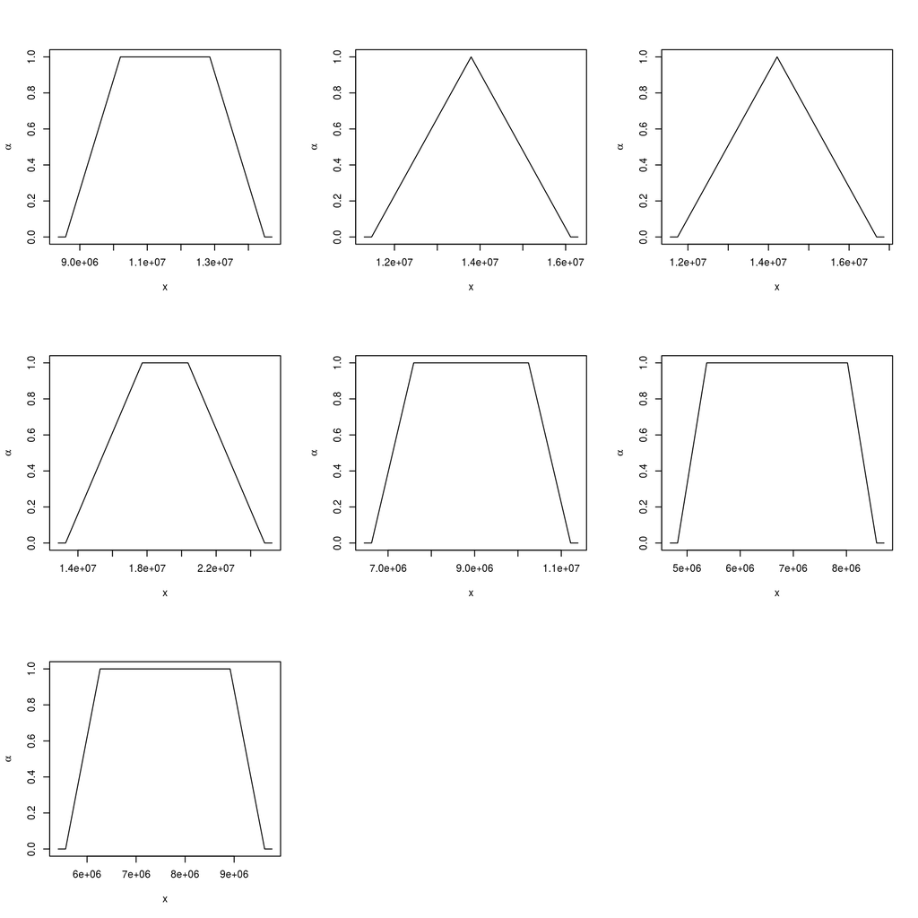

```r
library(FuzzyNumbers)

aux1 = df$turistas - (df$imprecision_carretera + df$imprecision_tren) - (df$turistas * df$porcentaje_tur)
aux2 = df$turistas - (df$imprecision_carretera + df$imprecision_tren)
aux3 = df$turistas + (df$imprecision_carretera + df$imprecision_tren)
aux4 = df$turistas + (df$imprecision_carretera + df$imprecision_tren) + (df$turistas * df$porcentaje_tur)

fuzzyNumbers = c()
par(mfrow = c(3, 3))
for(i in 1:nrow(df)) {
  fuzzy = PiecewiseLinearFuzzyNumber(aux1[i], aux2[i], aux3[i], aux4[i])
  fuzzyNumbers = c(fuzzyNumbers, fuzzy)
  plot(fuzzy, main = df$comunitat[i])
}
```

## Ejercicio 4

**Calcula, mediante la suma *fuzzy*, la suma de todos los turistas internacionales visitantes de España en el 2017. Compáralo con el dato *crisp*.**

La suma **fuzzy** se realiza de la siguiente forma:

```r
fuzzy_numTurism = 0
for(i in 1:length(fuzzyNumbers)) {
  fuzzy_numTurism = fuzzyNumbers[[i]] + fuzzy_numTurism
}
core(fuzzy_numTurism)
```

```
## [1] 75160778 88411948
```

Y la forma **crisp** de la siguiente forma:

```r
sum(df$turistas)
```

```
## [1] 81786363
```

## Ejercicio 5

**Calcula el porcentaje de visitantes respecto a la población de cada comunidad de forma *crisp* y de forma *fuzzy*. Compara los resultados (podéis suponer la población de cada comunidad de manera *crisp*). Analiza los resultados.**

Mientras que los números clásicos son muy tajantes a la par que imprecisos, nuestros datos fuzzyficados nos proporcionan una información adicional, referente a posibles errores en la imprecisión, que deja ver que el valor real puede distanciarse del valor central, aunque cada vez de forma más improbable.

```r
turist_pobl_crisp = c()
turist_pobl_fuzzy = c()

for(i in 1:nrow(df)){
  turist_pobl_crisp = c(turist_pobl_crisp, df$turistas[[i]] / df$poblacion[i])
  turist_pobl_fuzzy = c(turist_pobl_fuzzy, fuzzyNumbers[[i]] / df$poblacion[i])
}

turist_pobl_crisp
```

```
## [1]  1.3720802 11.8827115  6.5672028  2.5552495  1.8081470  1.0289327
## [7]  0.4766371
```

```r
turist_pobl_fuzzy
```

```
## [[1]]
## Piecewise linear fuzzy number with 0 knot(s),
##    support=[1.02096,1.7232],
##       core=[1.21439,1.52977].
##
## [[2]]
## Piecewise linear fuzzy number with 0 knot(s),
##    support=[9.87903,13.8864],
##       core=[11.8827,11.8827].
##
## [[3]]
## Piecewise linear fuzzy number with 0 knot(s),
##    support=[5.42589,7.70852],
##       core=[6.5672,6.5672].
##
## [[4]]
## Piecewise linear fuzzy number with 0 knot(s),
##    support=[1.7824,3.3281],
##       core=[2.37748,2.73302].
##
## [[5]]
## Piecewise linear fuzzy number with 0 knot(s),
##    support=[1.34232,2.27398],
##       core=[1.53949,2.07681].
##
## [[6]]
## Piecewise linear fuzzy number with 0 knot(s),
##    support=[0.741046,1.31682],
##       core=[0.82527,1.2326].
##
## [[7]]
## Piecewise linear fuzzy number with 0 knot(s),
##    support=[0.349199,0.604075],
##       core=[0.393443,0.559831].
```